# text mining with R

2020-08-29

I like how text mining gets easier by the day with advent of new methods and approach. I have been using the tidytext package for some time now, for someone who is already familiar with the tidymodels framework and how the recipe package can be utilized, i find textrecipe very useful. Personally i think textrecipe is currently the best and most easy-to-use tool for text mining in R.  
Before we go into practical example let’s first understand what text mining is.

## What is text mining?

In the world we are today a lot of big companies and organizations have started incorporaing the “data-driven” approach in their day-to-day acticivies, hence the need for efficient text mining process.  
**Text mining or text data mining, similar to text analytics, is the process of deriving high quality information from text.**

Textrecipe is an extension of the r recipe package for text processing, it is currently being maintained by `Emil Hvitfeldt`.

EXAMPLE

For this example we will make use of a dataset made available to us by `Cochtane`. He did a great job scraping the data from a popular Nigerian Forum [nairaland](https://nairaland.com) . Nairaland is an online community and public space that serves as a meeting place for Nigerians at Home and in the Diaspora. The dataset contains information about posts that were featured in the frontpage of the forum over a period of 1 year. The dataset has about 28,800 observations and 7 variables/features, Our focus however will only be on 2 variables:  
`title` **===>** Title of each post  
`section` **===>** section/category the post falls under

Our aim is to create a model that will take the title of a post and predict which section the post fall under..

Eventho we have the `section` variable which should serve as our target variable (suppose we want to create a supervised classification model) we are not going to make use of the variable, we will create an unsupervised model using the k-means algorithm with the `title` variable and evaluate the performance of the model with the `section` variable.

```r
require(tidyverse)
require(tidytext)
require(wordcloud2)
require(reactable)
```

```r
wire <- read_csv("C:/Users/wirelex/Desktop/dataset/nl_data.csv") %>%
  select(title, section)
```

## EXPLORATORY ANALYSIS

**See what the content of the variables look like**

```r
reactable(head(wire))
```

| title | section |
| --- | --- |
| Rape In Church: Edo State First Lady Pays Condolence Visit To Family Of Late Uwa | Politics |
| Bayelsa: Produce Your NYSC Certificate – Tribunal Orders Governor Diri’s Deputy | Politics |
| COVID-19: Governor Ikpeazu's Two Aides Test Positive | Health |
| Man Kills His Friend Over Ownership Of Girlfriend In Bauchi | Crime |
| Pastor And His Wife Killed In Taraba State (Photos) | Crime |
| Churches And Mosques To Remain Closed In Lagos | Religion |

### Let’s first explore the `section` variable

```r
wire %>% count(section) %>% arrange(desc(n))
```

```
## # A tibble: 37 x 2
##    section         n
##    <chr>       <int>
##  1 Politics     9892
##  2 Celebrities  4095
##  3 Crime        2932
##  4 Sports       2023
##  5 Health       1581
##  6 Religion     1090
##  7 Travel       1090
##  8 Education     892
##  9 Romance       858
## 10 Business      615
## # ... with 27 more rows
```

There are 37 different categories in the `section` variable. Working with such number of categories for a response variable in a classification model is out of the scope of this lesson so we may have to create a “other” category and collapse all the infrequent categories into it.

**let’s also view the counts in a plot**

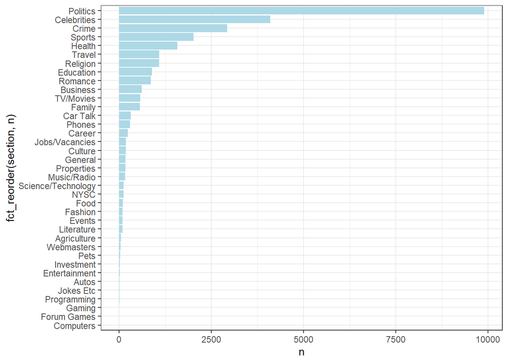

```r
wire %>% count(section) %>%
  ggplot(aes(fct_reorder(section, n), n)) + geom_col(fill = "lightblue") + coord_flip() +
  theme_bw()
```

We can see from the plot above that categories like computers, gaming, autos had very few posts in them, and categories like Politics, Celebrities, Crime are where most of the posts that were featured on the forum fall under.

### Let’s also explore the `title` variable

**A wordcloud of the top most frequent words that appeared in the title variable**

```r
wire_cloud <- wire %>% select(title) %>%
  unnest_tokens(word, title) %>%
  count(word, sort = TRUE) %>%
  filter(n>200)
```

Let’s try and workthrough the code above:  
* First the `select` function was used to select the column of interest **title**  
* then the `unnest_tokens` function from the tidytext package was used to break the **title** text into individual tokens (a process called tokenization) and transform it to a tidy data structure + A token is a meaningful unit of text, most often a word, that we are interested in using for further analysis, and tokenization is the process of splitting text into tokens.  
* we then used the `count` function to compute the count/frequency of each word and sorted the counts in descending order * the `filter` function was then used to filter out words that didn’t appear up to **200** times i.e words whose frequency were not up to 200

[output not shown]

- going further we used the `anti_join` function to filter out stopwords, the **get_stopwords** function as a parameter in the `anti_join` function provided an in-built vector of stopwords that we could match with what we have and get rid of.
  - Stopwords are a set of commonly used words like “a”, “the”, “are”, etc…. that carry very little useful information
- again we filtered out words like “pictures”, “photos”, “video”, “photo”, “pix” and “pics” that didn’t add useful information
- finally, all numeric strings were removed with the `str_remove` function and then we used the `wordcloud2` package to make a wordcloud plot.